# Function Library

R is a powerful programming language designed for professional-level statistical computing. We only deal with a few basic R functions in this textbook. We here provide a library of the functions you will learn and use as you work through this textbook. Each function includes descriptions and examples. Use this library as a reference as needed.

## `barplot(height, names)`

Creates a bar chart. The heights of the bars are given in the list `height` and the names of the bars are given in the list `names`. First introduced in [Section 1.5](https://profbaldwin.github.io/IntroductoryStatistics/Ch1%20Sampling%20and%20Data/1.5%20Tables%20and%20Charts.html).

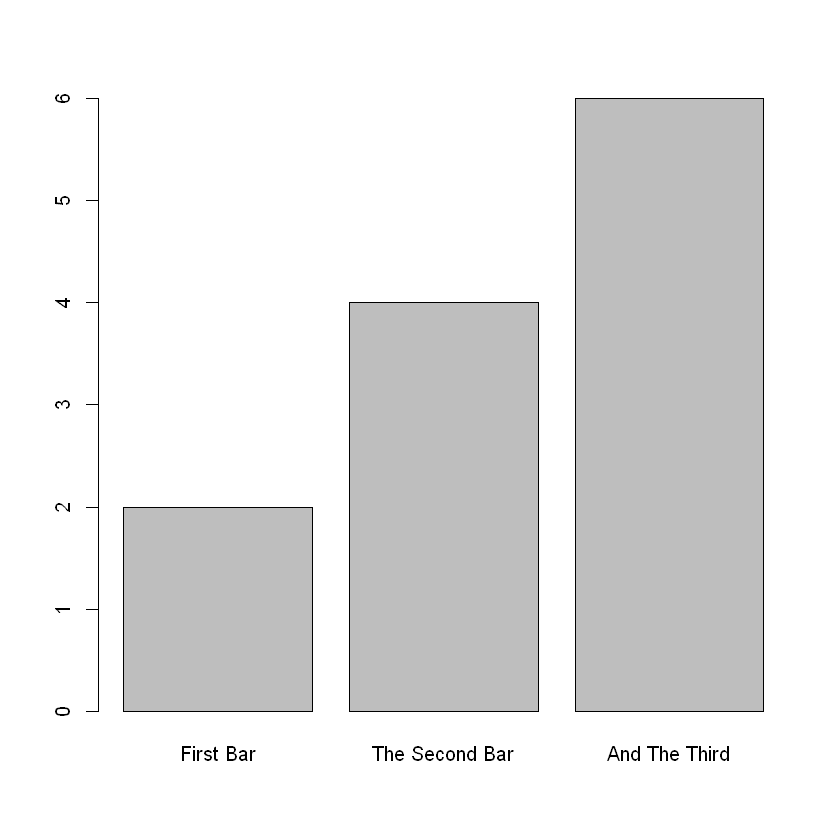

```r
barplot(height = c(2, 4, 6), names = c("First Bar", "The Second Bar", "And The Third"))
```

## `boxplot(x)`

Creates a box plot of the data in list `x`.

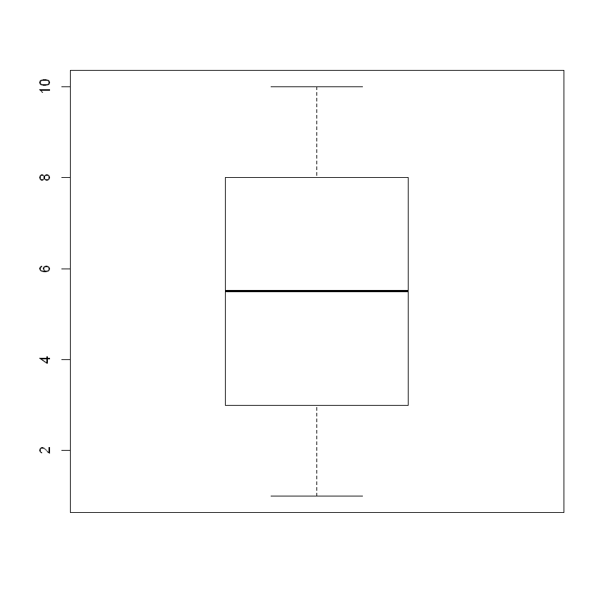

```r
boxplot(x = c(1, 2, 3, 4, 5, 6, 7, 8, 9, 10))
```

## `cor(x, y)`

The function returns the correlation coefficient corresponding to the list of $(x, y)$ points with $x$-values stored in list `x` and $y$-values stored in list `y`. First introduced in [Section 8.4](https://profbaldwin.github.io/IntroductoryStatistics/Ch8%20Correlation%20and%20Linear%20Regression/8.4%20The%20Correlation%20Coefficient.html).

```r
cor(x = c(1, 2, 3, 4), y = c(4, 1, 3, 2))
```

-0.4

So the correlation coefficient for the points $(1, 4)$, $(2, 1)$, $(3, 3)$, and $(4, 2)$ is $r = -0.4$.

## `dbinom(x, size, prob)`

Given a binomial distribution of `size` trials and probability of success `prob`, the function calculates the probability of having `x` successes, where `x` can be a single value or a list of values. First introduced in [Section 3.5](https://profbaldwin.github.io/IntroductoryStatistics/Ch3%20Probability/3.5%20The%20Binomial%20Distribution.html).

```r
dbinom(x = 7, size = 10, prob = 0.35)
```

0.0212030152851563

So if there is a probability of success of 0.35 for each trial, the probability of 7 successful trials out of 10 total is 0.0212.

```r
dbinom(x = c(2, 4, 6), size = 12, prob = 0.67)
```

1. 0.000453767032280239

2. 0.0140286515696005

3. 0.107945471263313

So given 12 trials with a probability of success of 0.67 for each trial, the probability that exactly 2 of the trials will be successful is 0.0004, the probability that exactly 4 of the trials will be successful is 0.0140, and the probability that exactly 6 of the trials will be successful is 0.1079.

## `hist(x)`

Creates a histogram using the data in list `x`. First introduced in [Section 1.5](https://profbaldwin.github.io/IntroductoryStatistics/Ch1%20Sampling%20and%20Data/1.5%20Tables%20and%20Charts.html).

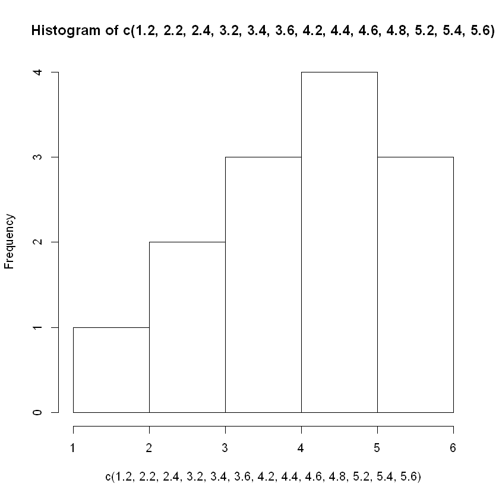

```r
hist(x = c(1.2, 2.2, 2.4, 3.2, 3.4, 3.6, 4.2, 4.4, 4.6, 4.8, 5.2, 5.4, 5.6))
```

## `length(x)`

Counts how many elements are in list `x`. First introduced in [Section 2.2](https://profbaldwin.github.io/IntroductoryStatistics/Ch2%20Descriptive%20Statistics/2.2%20Measures%20of%20Central%20Tendency.html).

```r
length(x = c(2, 4, 6))
```

3

There are 3 total elements in the list.

## `lm(y~x)`

Given a list of points with the $x$-values in list `x` and the $y$-values in list `y`, the function returns the coefficients of the **l**inear **m**odel that best fits the data. Note that the lists of $x$-values and $y$-values must first be stored in variables before use. First introduced in [Section 8.3](https://profbaldwin.github.io/IntroductoryStatistics/Ch8%20Correlation%20and%20Linear%20Regression/8.3%20The%20Regression%20Equation.html).

```r
x <- c(1, 2, 3, 4)
y <- c(4, 3, 1, 2)
lm(y ~ x)
```

```
Call:
lm(formula = y ~ x)

Coefficients:
(Intercept)            x
        4.5         -0.8
```

The line that best fits the points $(1, 4)$, $(2, 3)$, $(3, 1)$, and $(4, 2)$ is $y = 4.5 - 0.8x$.

## `median(x)`

Finds the median value of list `x`. First introduced in [Section 2.2](https://profbaldwin.github.io/IntroductoryStatistics/Ch2%20Descriptive%20Statistics/2.2%20Measures%20of%20Central%20Tendency.html).

```r
median(x = c(7, 11, 2, 19, 45, 12, 31))
```

12

If we line up all the values in the list in order, 12 will be the value in the middle. It is the median of the data.

## `pchisq(q, df, lower.tail)`

If the `lower.tail` is set to `TRUE`, the function calculates the probability *left* of the $\chi^2$-score `q` in the $\chi^2$-distribution with `df` degrees of freedom. If the `lower.tail` is set to `FALSE`, the function calculates the probability *right* of the $\chi^2$-score `q` in the $\chi^2$-distribution with `df` degrees of freedom. First introduced in [Section 7.1](https://profbaldwin.github.io/IntroductoryStatistics/Ch7%20The%20Chi-Square%20Distribution/7.1%20The%20Chi-Square%20Distribution.html).

```r
pchisq(q = 10, df = 8, lower.tail = TRUE)
```

0.734974084702638

Given a $\chi^2$ distribution with 8 degrees of freedom, the area or probability to the left of $\chi^2 = 10$ is about 0.7350.

```r
pchisq(q = 20, df = 24, lower.tail = FALSE)
```

0.696776146303107

Given a $\chi^2$ distribution with 24 degrees of freedom, the area or probability to the right of $\chi^2 = 20$ is about 0.6968.

## `pf(q, df1, df2, lower.tail)`

```r
pf(q = 0.5, df1 = 5, df2 = 1, lower.tail = TRUE)
```

0.216437229269686

Given an $F$-distribution with numerator degrees of freedom $df_1 = 5$ and denominator degrees of freedom $df_2 = 1$, the probability or area to the left of $F = 0.5$ is about 0.2164.

```r
pf(q = 1.0, df1 = 10, df2 = 10, lower.tail = FALSE)
```

0.5

Given an $F$-distribution with numerator degrees of freedom $df_1 = 10$ and denominator degrees of freedom $df_2 = 10$, the probability or area to the right of $F = 1.0$ is 0.5.

## `pie(x, labels)`

Creates a pie chart. Here, `x` is a list of quantities for each category, and `labels` is a list of labels for those categories. First introduced in [Section 1.5](https://profbaldwin.github.io/IntroductoryStatistics/Ch1%20Sampling%20and%20Data/1.5%20Tables%20and%20Charts.html).

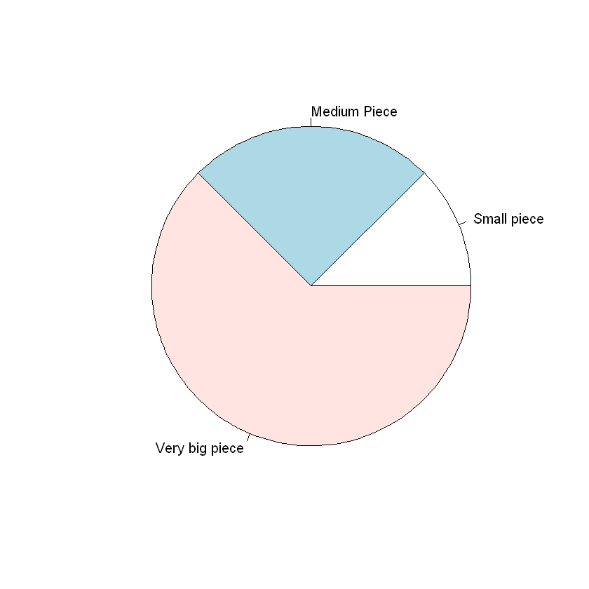

```r
pie(x = c(30, 60, 150), labels = c("Small piece", "Medium Piece", "Very big piece"))
```

## `plot(x, y)`

Creates a scatter plot using the $(x, y)$ pairs formed from the values in list `x` and list `y`. First introduced in [Section 8.1](https://profbaldwin.github.io/IntroductoryStatistics/Ch8%20Correlation%20and%20Linear%20Regression/8.1%20Scatter%20Plots.html).

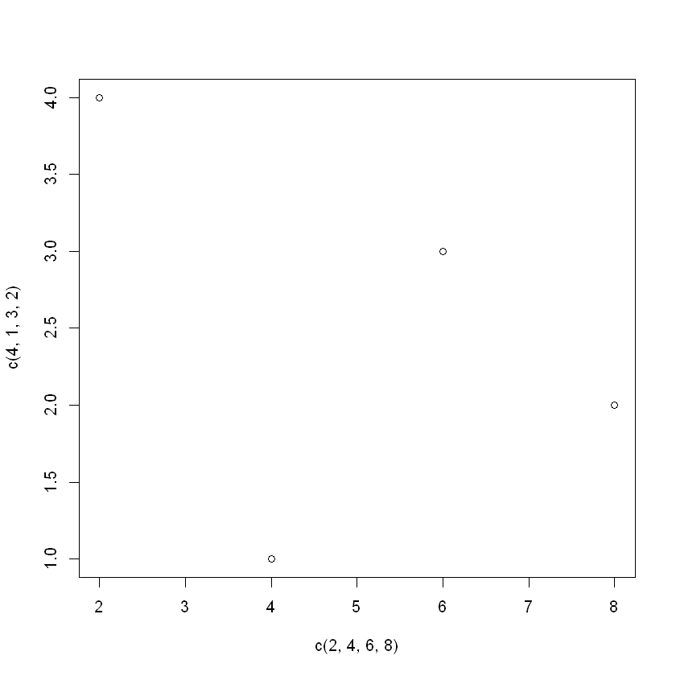

```r
plot(x = c(2, 4, 6, 8), y = c(4, 1, 3, 2))
```

Note that the points plotted are $(2, 4)$, $(4, 1)$, $(6, 3)$, and $(8, 2)$.

## `pnorm(q, lower.tail)`

If the `lower.tail` is set to `TRUE`, the function calculates the probability *left* of the $z$-score `q` in the standard normal distribution. If the `lower.tail` is set to `FALSE`, the function calculates the probability *right* of the $z$-score `q` in the standard normal distribution. This is the reverse of the `qnorm` function. First introduced in [Section 4.1](https://profbaldwin.github.io/IntroductoryStatistics/Ch4%20The%20Normal%20Distribution%20and%20the%20Central%20Limit%20Theorem/4.1%20The%20Standard%20Normal%20Distribution.html).

```r
pnorm(q = 0, lower.tail = TRUE)
```

0.5

So given the standard normal distribution, the area or probability to the left of $z = 0$ is 0.5.

```r
pnorm(q = -1.475, lower.tail = FALSE)
```

0.929893728288777

So given the standard normal distribution, the area or probability to the right of $z = -1.475$ is about 0.9299.

## `pt(q, df, lower.tail)`

If the `lower.tail` is set to `TRUE`, the function calculates the probability *left* of the $t$-score `q` in Student's $t$-distribution with `df` degrees of freedom. If the `lower.tail` is set to `FALSE`, the function calculates the probability *right* of the $t$-score `q` in Student's $t$-distribution with `df` degrees of freedom. The is the reverse of the `qt` function. First introduced in [Section 5.3](https://profbaldwin.github.io/IntroductoryStatistics/Ch5%20Confidence%20Intervals/5.3%20Student's%20t-Distribution).

```r
pt(q = 1.5, df = 6, lower.tail = TRUE)
```

0.907859631929259

Given a $t$-distribution with 6 degrees of freedom, the area or probability to the left of $t = 1.5$ is about 0.9079.

```r
pt(q = -0.5, df = 12, lower.tail = FALSE)
```

0.686941261887338

Given a $t$-distribution with 12 degrees of freedom, the area or probability to the right of $t = -0.5$ is about 0.6869.

## `qnorm(p, lower.tail)`

If `lower.tail` is set to `TRUE`, the function finds the $z$-score in the standard normal distribution with probability `p` to the *left* of that $z$-score. If `lower.tail` is set to `FALSE`, the function finds the $z$-score in the standard normal distribution with probability `p` to the *right* of that $z$-score. This is the reverse of the `pnorm` function. First introduced in [Section 4.1](https://profbaldwin.github.io/IntroductoryStatistics/Ch4%20The%20Normal%20Distribution%20and%20the%20Central%20Limit%20Theorem/4.1%20The%20Standard%20Normal%20Distribution.html).

```r
qnorm(p = 0.5, lower.tail = TRUE)
```

0

Given the standard normal distribution, the $z$-score with an area or probability of 0.5 to its left is $z = 0$.

```r
qnorm(p = 0.9299, lower.tail = FALSE)
```

-1.47504665754652

Given the standard normal distribution, the $z$-score with an area or probability of 0.9299 to its right is about $z = -1.4750$.

## `qt(p, df, lower.tail)`

If `lower.tail` is set to `TRUE`, the function finds the $t$-score in Student's $t$-distribution with `df` degrees of freedom and with probability `p` to the *left* of that $t$-score. If `lower.tail` is set to `FALSE`, the function finds the $t$-score in Student's $t$-distribution with `df` degrees of freedom and with probability `p` to the *right* of that $t$-score. This is the reverse of the `pt` function. First introduced in [Section 5.3](https://profbaldwin.github.io/IntroductoryStatistics/Ch5%20Confidence%20Intervals/5.3%20Student's%20t-Distribution).

```r
qt(p = 0.8, df = 3, lower.tail = TRUE)
```

0.978472312363304

Given a $t$-distribution with 3 degrees of freedom, the $t$-score with an area or probability of 0.8 to its left is about $t = 0.9785$.

```r
qt(p = 0.6, df = 7, lower.tail = FALSE)
```

-0.263166861352023

Given a $t$-distribution with 7 degrees of freedom, the $t$-score with an area or probability of 0.6 to its right is about $t = -0.2632$.

## `quantile(x, probs)`

Finds the percentile or list of percentiles of the data in list `x` corresponding to the percentages, in decimal form, in `probs`. `probs` may be a single value or a list of values, but the values must always be between 0 = 0% and 1 = 100%. First introduced in [Section 2.1](https://profbaldwin.github.io/IntroductoryStatistics/Ch2%20Descriptive%20Statistics/2.1%20Measures%20of%20Position.html).

```r
quantile(x = c(1, 2, 3, 4), probs = 0.50)
```

**50%:** 2.5

So the 50th percentile of the data is 2.5. That is, about 50% of the data values are less than 2.5.

```r
quantile(x = c(1, 2, 3, 4), probs = c(0.10, 0.90))
```

**10%**

1.3

**90%**

3.7

So the 10th percentile of the data is 1.3, and the 90th percentile of the data is 3.7. That is, about 10% of the data is less than 1.3, and about 90% of the data is less than 3.7.

## `sample(x, size)`

Randomly samples `size` elements from list `x`. First introduced in [Section 1.3](https://profbaldwin.github.io/IntroductoryStatistics/Ch1%20Sampling%20and%20Data/1.3%20Sampling%20Techniques.html).

```r
sample( x = c(1, 2, 3, 4, 5, 6, 7, 8, 9), size = 3 )
```

1. 7

2. 2

3. 4

The three numbers 7, 2, and 4 were randomly sampled from the list of values.

## `sqrt(x)`

Finds the positive square root of `x`. If `x` is a list of values, then `sqrt` will find the square root of each value in the list. First introduced in [Section 2.3](https://profbaldwin.github.io/IntroductoryStatistics/Ch2%20Descriptive%20Statistics/2.3%20Measures%20of%20Dispersion.html)

```r
sqrt(x = 4)
```

2

The square root of 4 is 2.

```r
sqrt(x = c(1, 4, 9, 20))
```

1. 1

2. 2

3. 3

4. 4.47213595499958

The square roots of 1, 4, 9, and 20 are, respectively, 1, 2, 3, and 4.4721.

## `sum(x)`

Adds together all the values in list `x`. First introduced in [Section 2.2](https://profbaldwin.github.io/IntroductoryStatistics/Ch2%20Descriptive%20Statistics/2.2%20Measures%20of%20Central%20Tendency.html).

```r
sum(x = c(1, 2, 3, 4))
```

10

So $1 + 2 + 3 + 4 = 10$.

**License:** This work is licensed under a [Creative Commons Attribution 4.0 International](https://creativecommons.org/licenses/by/4.0/) license.

**Author:** Taylor Baldwin, Mt. San Jacinto College

**Adapted From:** *Introductory Statistics*, by Barbara Illowsky and Susan Dean. Access for free at [https://openstax.org/books/introductory-statistics/pages/1-introduction](https://openstax.org/books/introductory-statistics/pages/1-introduction).